# Final Project IS605

Sharon Morris

5/06/2017

*Kaggle.com Home Price Completion*

**1. You are to register for Kaggle.com (free) and compete in the House Prices: Advanced Regression Techniques competition.**

*House Prices: Advanced Regression Techniques competition* Ask a home buyer to describe their dream house, and they probably won’t begin with the height of the basement ceiling or the proximity to an east-west railroad. But this playground competition’s dataset proves that much more influences price negotiations than the number of bedrooms or a white-picket fence.

With 79 explanatory variables describing (almost) every aspect of residential homes in Ames, Iowa, this competition challenges you to predict the final price of each home.

**Load Library**

```r
library(formattable)
library(stats)
require(dplyr)
library(MASS)

devtools::install_github("rubenarslan/formr")
```

# 1. Define Variables

Pick one of the quantitative independent variables from the training data set (train.csv) , and define that variable as X. Pick SalePrice as the dependent variable, and define it as Y for the next analysis.

```r
summary(X)
```

```
   Min. 1st Qu.  Median    Mean 3rd Qu.    Max.
    0.0     0.0   383.5   443.6   712.2  5644.0
```

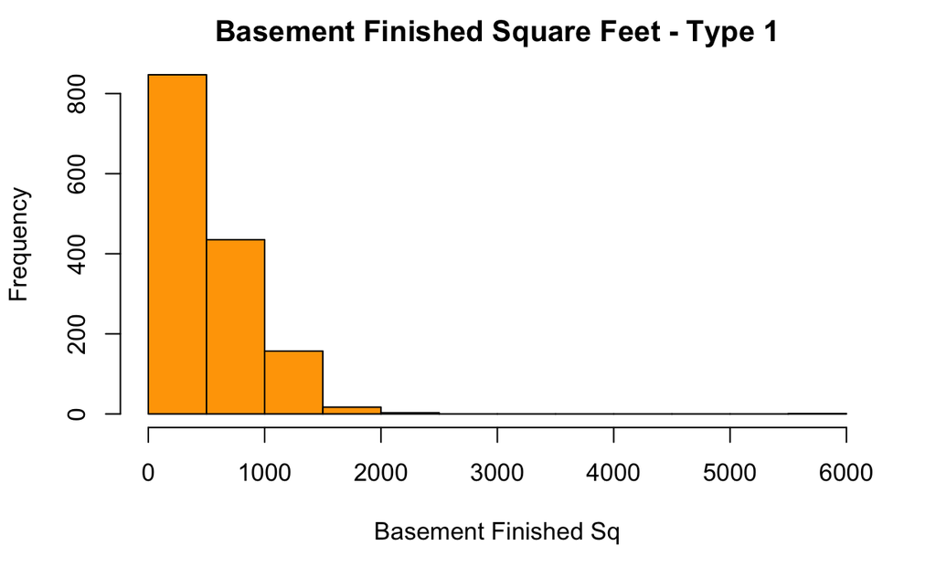

# 2. Probability

```r
quantile(X)
```

```
     0%     25%     50%     75%    100%
   0.00    0.00  383.50  712.25 5644.00
```

```r
(sum(Y > 163000 & X > 6) / length(X)) / (sum(Y > 163000) / length(Y))
```

```
[1] 0.7046703
```

2. $P(X>x, Y>y)$

```r
sum(X > 6 & Y > 163000) / length(X)
```

```
[1] 0.3513699
```

3. $P(X<x | Y>y)$

```r
(sum(Y > 163000 & X < 6) / length(X)) / (sum(Y > 163000) / length(Y))
```

```
[1] 0.2953297
```

**Count Table**

```r
#Sum rows with sales prices > 163000
(YQ2 <- sum(Y > 163000))
```

```
[1] 728
```

```r
#Count of all rows sales prices
(YTotal <- length(Y))
```

```
[1] 1460
```

```r
#Count of all rows of overall condition
(XTotal <- length(X))
```

```
[1] 1460
```

```r
#Rows greater than 163,000 and greater than 6
(Ygt <- sum(Y > 163000 & X > 6))
```

```
[1] 513
```

```r
#Rows greater than 163,000 and less than 6
(Ylt <- sum(Y > 163000 & X < 6))
```

```
[1] 215
```

```r
sum(train[,'BsmtFinSF1'] <= 6 & train[,'SalePrice'] > 163000)
```

```
[1] 215
```

```r
sum(train[,'BsmtFinSF1'] > 6 & train[,'SalePrice'] <= 163000)
```

```
[1] 479
```

```r
sum(train[,'BsmtFinSF1'] > 6 & train[,'SalePrice'] > 163000)
```

```
[1] 513
```

[output not shown]

$P(A|B)\neq P(A)P(B)$ indicates splitting the data in this fashion did not make them independent.

```r
#Assign to variables
PA <- 299/1657
PB <- 728/1657

#P(A) * P(B)
(AXB <- PA*PB)

#Convert to a percent
percent(AXB)

#P(A|B)
PAl <- 98/1657
PBl <- 1657/728

(PABl <- PAl*PBl)
percent(PABl)
```

[output not shown]

**Evaluate by running a Chi Square test for association.**

```r
#Pearson's Chi Square test with Yates -- 2x2 table
chisq.test(matrix(c(728, 630, 201, 98), ncol=2))
```

[output not shown]

# 3. Descriptive and Inferential Statistics

Transform both variables simultaneously using Box-Cox transformations. You might have to research this. Using the transformed variables, run a correlation analysis and interpret. Test the hypothesis that the correlation between these variables is 0 and provide a 99% confidence interval. Discuss the meaning of your analysis.

```r
#Examine variable names
names(train)
```

```r
library(UsingR, quietly = TRUE, warn.conflicts = FALSE)
```

[output not shown]

*Provide univariate descriptive statistics*

```r
#Mean,median,25th and 75th quartiles,min,max
summary(numericV)
```

```
   SalePrice      EnclosedPorch      BsmtFinSF1        LotArea
 Min.   : 34900   Min.   :  0.00   Min.   :   0.0   Min.   :  1300
 1st Qu.:129975   1st Qu.:  0.00   1st Qu.:   0.0   1st Qu.:  7554
 Median :163000   Median :  0.00   Median : 383.5   Median :  9478
 Mean   :180921   Mean   : 21.95   Mean   : 443.6   Mean   : 10517
 3rd Qu.:214000   3rd Qu.:  0.00   3rd Qu.: 712.2   3rd Qu.: 11602
 Max.   :755000   Max.   :552.00   Max.   :5644.0   Max.   :215245
```

*Provide a scatterplot of X and Y.*

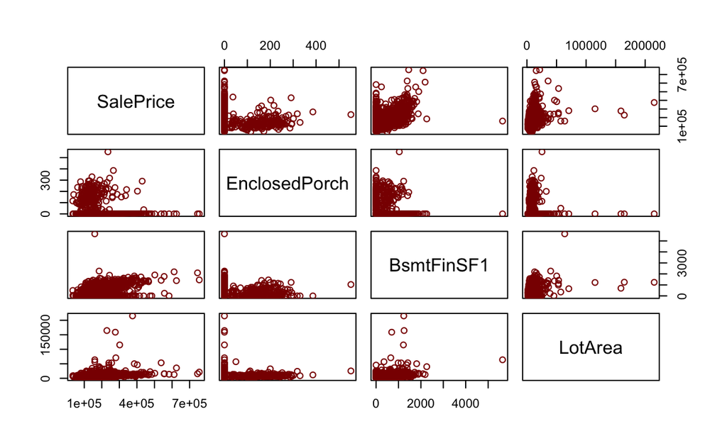

```r
#Look at all the relationships in selected variables
plot(numericV, col="darkred")
```

Test the hypothesis that the correlation between these variables is 0 and provide a 99% confidence interval.

```r
var <- data.frame(train$BsmtFinSF1, train$SalePrice)
cor(var)
```

```
                 train.BsmtFinSF1 train.SalePrice
train.BsmtFinSF1        1.0000000       0.3864198
train.SalePrice         0.3864198       1.0000000
```

```r
cor.test(train$BsmtFinSF1, train$SalePrice, conf.level = 0.99)
```

```
    Pearson's product-moment correlation

data:  train$BsmtFinSF1 and train$SalePrice
t = 15.998, df = 1458, p-value < 2.2e-16
alternative hypothesis: true correlation is not equal to 0
99 percent confidence interval:
 0.3275690 0.4422838
sample estimates:
      cor
0.3864198
```

# 4. Linear Algebra and Correlation

Invert your correlation matrix. (This is known as the precision matrix and contains variance inflation factors on the diagonal.) Multiply the correlation matrix by the precision matrix, and then multiply the precision matrix by the correlation matrix.

The table below show correlations coefficients between the possible pairs of variables

```r
d <- select(train, BsmtFinSF1, SalePrice)
(corMatrix <- cor(d))  #Correlation matrix
```

```
           BsmtFinSF1 SalePrice
BsmtFinSF1  1.0000000 0.3864198
SalePrice   0.3864198 1.0000000
```

```r
round(corMatrix, 3)
```

```
           BsmtFinSF1 SalePrice
BsmtFinSF1      1.000     0.386
SalePrice       0.386     1.000
```

```r
#The inverse of the correlation matrix
(preMatrix <- solve(corMatrix))
```

```
           BsmtFinSF1  SalePrice
BsmtFinSF1  1.1755305 -0.4542483
SalePrice  -0.4542483  1.1755305
```

```r
round(preMatrix, 3)
```

```
           BsmtFinSF1 SalePrice
BsmtFinSF1      1.176    -0.454
SalePrice      -0.454     1.176
```

Multiply the correlation matrix by the precision matrix, and the precision matrix by the correlation matrix

```r
corMatrix %*% preMatrix #Correlation * precision
```

```
             BsmtFinSF1 SalePrice
BsmtFinSF1 1.000000e+00         0
SalePrice  5.551115e-17         1
```

```r
preMatrix %*% corMatrix #Precision * correlation
```

```
           BsmtFinSF1    SalePrice
BsmtFinSF1          1 5.551115e-17
SalePrice           0 1.000000e+00
```

# 5. Calculus-Based Probability & Statistics

For your non-transformed independent variable, location shift it so that the minimum value is above zero. Then load the MASS package and run fitdistr to fit a density function of your choice. (See $\url{https://stat.ethz.ch/R-manual/R-devel/library/MASS/html/fitdistr.html$}). Find the optimal value of the parameters for this distribution, and then take 1000 samples from this distribution (e.g., $rexp(1000, λ$) for an exponential). Plot a histogram and compare it with a histogram of your non-transformed original variable.

```r
#Fits the exponential distribution to the data
fitDist <- fitdistr(X,"exponential")
(lam <- fitDist$estimate)  #Lambda
```

```
       rate
0.002254081
```

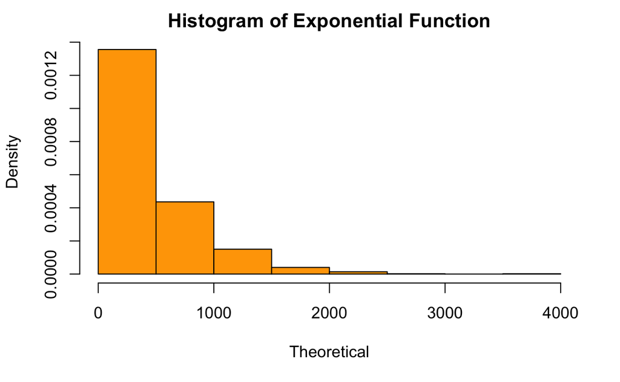

```r
#Get values from the exponential distribution
n <- rexp(1000, lam)
#Histogram of the exponential
hist(n, prob=TRUE, col="orange", main = "Histogram of Exponential Function", xlab="Theoretical")
```

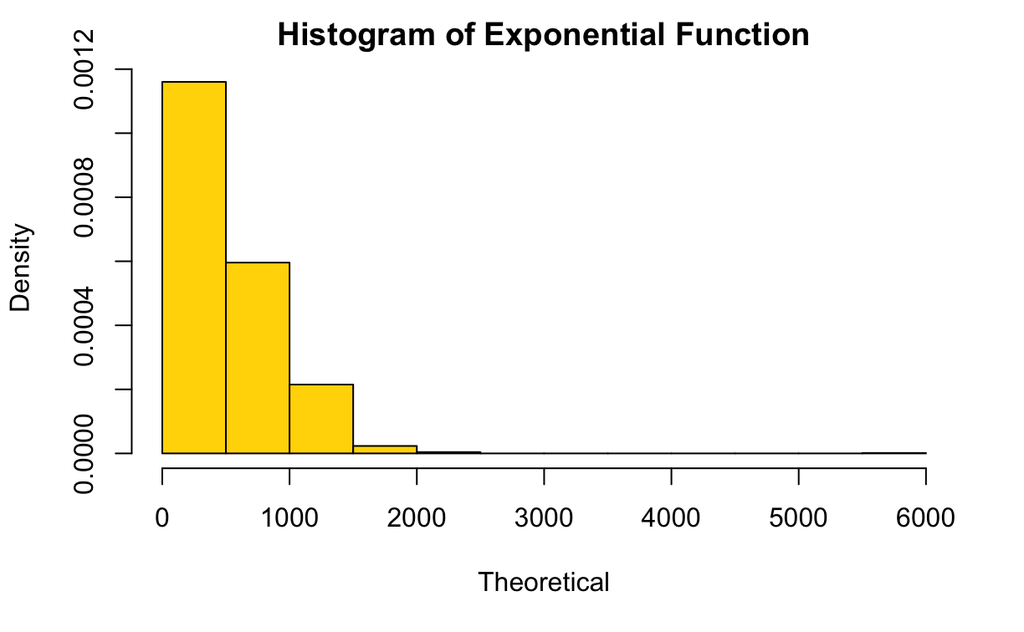

```r
#Hitogram of the OverCond
hist(train$BsmtFinSF1, prob=TRUE, col="gold", main = "Histogram of Exponential Function", xlab="Theoretical")
```

# 6. Modeling

Build some type of regression model and submit your model to the competition board. Provide your complete model summary and results with analysis.

$Y=\beta_0+\beta_1X_1+\beta_2X_2+e$ $Y$= Sale Price - Response variable $B_1$= BasementFinSF1 - First regression coefficient $B_2$= Lot Area - Second regression coefficient

```r
#Correlation
cor(na.omit(cbind(numericV, Y)))
```

```
               SalePrice EnclosedPorch BsmtFinSF1     LotArea          Y
SalePrice      1.0000000   -0.12857796  0.3864198  0.26384335  1.0000000
EnclosedPorch -0.1285780    1.00000000 -0.1023033 -0.01833973 -0.1285780
BsmtFinSF1     0.3864198   -0.10230331  1.0000000  0.21410313  0.3864198
LotArea        0.2638434   -0.01833973  0.2141031  1.00000000  0.2638434
Y              1.0000000   -0.12857796  0.3864198  0.26384335  1.0000000
```

```
Call:
lm(formula = SalePrice ~ BsmtFinSF1 + LotArea, data = train)

Residuals:
    Min      1Q  Median      3Q     Max
-414754  -47826  -15561   33074  496521

Coefficients:
             Estimate Std. Error t value Pr(>|t|)
(Intercept) 1.383e+05  3.087e+03  44.810  < 2e-16 ***
BsmtFinSF1  6.023e+01  4.221e+00  14.270  < 2e-16 ***
LotArea     1.511e+00  1.929e-01   7.833 9.11e-15 ***
---
Signif. codes:  0 ‘***’ 0.001 ‘**’ 0.01 ‘*’ 0.05 ‘.’ 0.1 ‘ ’ 1

Residual standard error: 71830 on 1457 degrees of freedom
Multiple R-squared:  0.1837,    Adjusted R-squared:  0.1826
F-statistic: 163.9 on 2 and 1457 DF,  p-value: < 2.2e-16
```

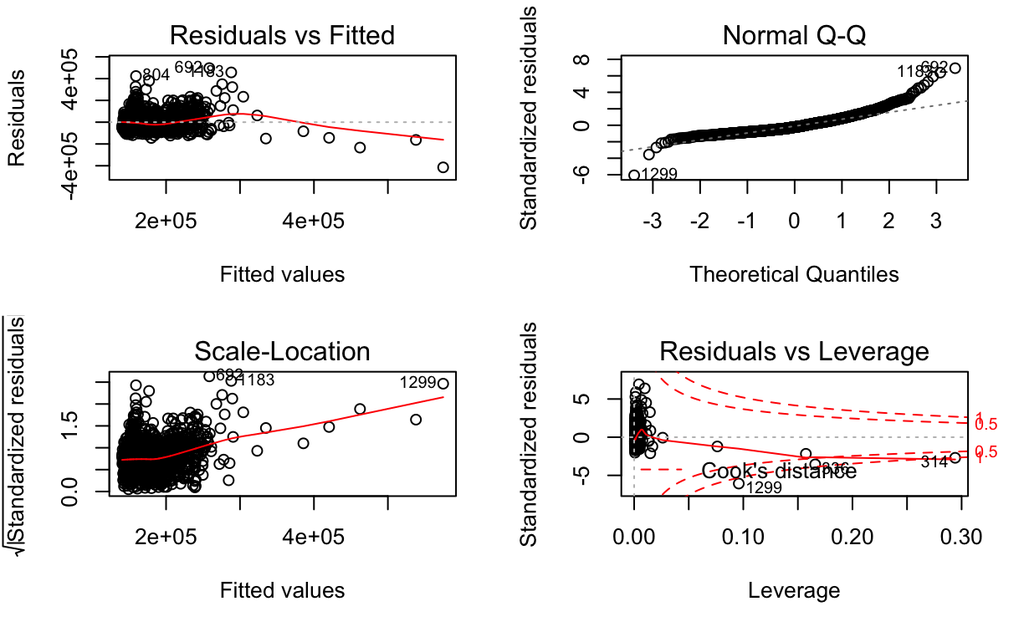

```r
fit <- lm(SalePrice ~ BsmtFinSF1 + LotArea, data = train)
(sum <- summary(fit)); par(mfrow = c(2, 2)); plot(fit)
```

```r
test <- read.csv(paste0("https://raw.githubusercontent.com/indianspice/IS605/master/Final%20Project/test.csv"), stringsAsFactors = F)
predictor1 <- test$BsmtFinSF1
predictor1 <- na.omit(predictor1) #Remove missing values
predictor2 <- test$LotArea
predictor2 <- na.omit(predictor2)
rFit <- as.data.frame(cbind("Id" = test[,"Id"],
                            "SalePrice" = fit$coefficients[1] +
                              fit$coefficients[2] * predictor1 +
                              fit$coefficients[3] * predictor2))
```

```
longer object length is not a multiple of shorter object length
```

```r
write.csv(rFit, "KaggleSubmission.csv", row.names = F)
```

```r
dim(rFit)
```

```
[1] 1459    2
```

**Kaggle Information**

**Refernces** http://stackoverflow.com/questions/24202120/dplyrselect-function-clashes-with-massselect http://stackoverflow.com/questions/11995832/inverse-of-matrix-in-r http://www.theanalysisfactor.com/interpreting-regression-coefficients/ https://rstudio-pubs-static.s3.amazonaws.com/234598_13317c1c83534900b9c36eda2f205a87.html#modeling

**Report your Kaggle.com**

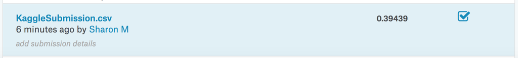